# Street Parking Occupancy Predictions in Seattle, WA

Leonardo Harth and Hyo Sung Kim

December 21, 2018

MUSA 507 (Fall 2018) Final Project

## 1. Introduction

#### Project Overview: The Problem the Use Case and Purpose

This model was built with the intent to correlate spatial and temporal data to parking occupancy ratios in Seattle,WA. The purpose of such an approach is to find out the characteristics of the built environment that attract more drivers to specific locations, and how this demand shifts during the day. By having these multiple variables is a single model, we expect to understand up to which degree each of those features affect the parking demand.

Such predictive power is extremely useful for urban planners, since parking is a serious problem in American cities. Municipal legislation often demands from new developments off-street parking requirements (mandatory parking minimums), which consume a large share of land - making new developments and consequently cities more expensive. This also incentivizes the use of personal vehicles over more environmentally friendly options, such as transit, biking, or walking.

Off-street parking requirements are not the only problem, though: an unbalanced offer of street parking brings an array of externalities. Vehicles in low speed searching for a parking stall in a busy areas of cities, which result in increased congestion. Charging the right fee for parking is challenging, but if the pricing is well designed, the city may maximize revenue and still have some empty spots throughout the day.

In this context, our model was conceived to help planners understand how their decisions affect the parking demands in the city. For example, when the zoning code is modified in a former industrial zone being redeveloped to accommodate commercial or residential functions, how does that affect parking demand? This can also be seen as how a specific building would affect the parking needs of a specific perimeter.

This model can be built into an app that forecasts different scenarios, which can be useful for quick consultations during a meeting or to evaluate long-term effects of policy changes. Furthermore, the app can be adapted in the future to provide price optimization, or to incorporate functionalities intended to the drivers, such as parking availability.

#### Results summary

In brief, our final model showed that the most significant predictors for estimating the average occupancy for a street segment was largely dependent on neighborhood characteristics such as time of the day, neighborhood location and street type, among other variables. The model could similarly predict for observed and unseen values. In conclusion, it is hard to say the model is generalizable because most of the data was trained from a dataset that mostly contained observations from the downtown area of Seattle. As such, it is more appropriate that this model is more accurate to predicting average parking occupancy for areas in downtown Seattle.

## 2. Data

#### 2.1 Used Data

The two main datasets used for this model analysis were the Annual Parking Study dataset and the Seattle Streets dataset.

The [Annual Parking Study Data](https://data.seattle.gov/Transportation/Annual-Parking-Study-Data/7jzm-ucez) for the city of Seattle contains a sample of the parking occupancy for street segments between 2014-2018. We have joined this data to the street pricing information for each year, by using the dynamic pricing rates found in the [On-Street Paid Parking Annual Report](https://www.seattle.gov/transportation/document-library/reports-and-studies#parking) published every year. The data is organized by street segment, which enables more specific outcomes.

The Seattle street network was fundamental to geolocate the street segments. It is also intrinsically helpful, since we added significant variables from this dataset, such as what type of street (local / collector / major), whether the street is one-way or two way, which side of the street people park, and the slope of the street.

To control for the built environment at those places, we have used the [building permits data](https://data.seattle.gov/Permitting/Building-Permits/76t5-zqzr), which comprises all building permits issued or in progress within the city of Seattle. We have also used the [zoning code](https://data.seattle.gov/dataset/City-Of-Seattle-Zoning/2hat-teay). We have joined both of these datasets to the Seattle street shapefile using ArcGIS. The shapefile we added to our R Script is named “streets_join_permits_zoning.shp”.

To incorporate the building permits into our model, we have handled them in two separate ways. First, we have determined for each street segment which is the most predominant type of use (the permits are classified as single family, multifamily, commercial, institutional, industrial, or vacant). While this approach gives us helpful insight regarding the composition of the parcel, it may distort situations in which a segment has, for instance, a hospital, and several houses. In this case, the prevalent use would be single family, but the hospital would create a huge demand. We have then decided to build a “parking score” for each segment, which is a weighted sum of all land uses within each parcel. Vacant parcels were multiplied by 3, single family by 4, multifamily by 6, industrial by 6, institutional by 8, and commercial by 10. This aggregate score was integrated as a variable called ‘wtScore’ in our model.

One promising variable that we looked at was the presence of public parking lots and garages. Our initial assumption is that those are built on places with high parking demand. So, we used ¼ Mile buffers as a dummy variable to verify if the segments were in one of those areas. However, the set of buffers of all public parking lots and garages ended up being one big shape that encompassed all the downtown area, where most of our observations are located, rendering this feature useless for our model.

#### 2.2 Feature Engineering and Data Wrangling

We first set our working directory and load the necessary libraries.

```r
#set working directory

#load libraries
library(sp)
library(rgdal)
library(sf)
library(tidyr)
library(dplyr)
library(lattice)
library(ggplot2)
library(caret)
library(tidycensus)
library(FNN)
library(Rcpp)
library(viridis)
options(scipen = 999)
```

#### Parking Data

We begin by cleaning the Parking Data. We loaded the initial parking data and eliminated observations with no segment description. Throughout the code, we ran the codes in “##” to make sure the correct changes are made.

```r
parking<-read.csv('C:/Users/angel/Dropbox/SPATIAL_ANALYSIS_FINAL/Annual_Parking_Study_Data_csv_Excel.csv')
parking2<-parking
parking2$Unitdesc[parking2$Date.Time=='1-00-00 00:00:00']<-NA
parking2<-subset(parking2,!is.na(parking2$Unitdesc))
```

We created columns noting the percentage of parked vehicles (completely full or not) and percent demand, which considered the number of parked cars beyond capacity. The additional demand column shows the count of cars that exceeded the number of spaces available.

```r
#percent full parking on segment
parking2$pctParking<-ifelse(parking2$Total_Vehicle_Count>parking2$Parking_Spaces,1,
                            parking2$Total_Vehicle_Count/parking2$Parking_Spaces)
parking2$pctParking<-ifelse(parking2$Total_Vehicle_Count==0 & parking2$Parking_Spaces==0,
                            0,parking2$pctParking)
parking2$pctParking<-parking2$pctParking*100
parking2<-subset(parking2[c(1:6,8,9,23,14:21)])

#percent demand
parking2$pctDemand<-ifelse(parking2$Total_Vehicle_Count==0 & parking2$Parking_Spaces==0,
                           0, ifelse(parking2$Parking_Spaces==0 & parking2$Total_Vehicle_Count>0,
                                     parking2$Total_Vehicle_Count/1, parking2$Total_Vehicle_Count/parking2$Parking_Spaces))
parking2$AdditionalDemand<-parking2$Total_Vehicle_Count-parking2$Parking_Spaces
parking2<-subset(parking2[c(1:9,18,19,10:17)])
```

The next step is to adjust the Date and Time column into two separate columns.

```r
#separate date.time column into two separate columns
parking3<-parking2
dateTimeSplit<-do.call(rbind,strsplit(as.character(parking3$Date.Time)," "))
dateTimeSplit<-as.data.frame(dateTimeSplit)
parking3<-cbind(parking3,Time=dateTimeSplit[,2],Date=dateTimeSplit[,1])
parking3<-subset(parking3[c(1:12,20,21,13:19)])
rm(dateTimeSplit)
```

Each observation in the parking survey recorded car counts during different times of the day. We aggregated the timestamps in morning (8-10am), afternoon (11am - 5pm), evening (6- 8pm) and night (9pm - 7am). The time aggregations were also based on the “On-Street Paid Parking Annual Report” for every year - they included information on when prices varied in different neighborhoods of Seattle.

```r
#combine into morning,afternoon,evening,nighttime periods
#check hour range
##levels(parking3$Time)
#run twice to just get the hour
parking3$Time<-substr(parking3$Time,1,nchar(as.character(parking3$Time))-3)
parking3$Time<-substr(parking3$Time,1,nchar(as.character(parking3$Time))-3)
parking3$DayPeriod<-ifelse(as.numeric(parking3$Time)>7&as.numeric(parking3$Time)<11,'Morning',
                           ifelse(as.numeric(parking3$Time)>10&as.numeric(parking3$Time)<18,'Afternoon',
                                  ifelse(as.numeric(parking3$Time)>17&as.numeric(parking3$Time)<21,'Evening','Night')))
#check appropriate classifications
##table(parking3$DayPeriod)
```

We select columns of interest and aggregated using the group_by() function.

```r
#copy and select columns of interest
parking3_2<-parking3
parking3_2<-subset(parking3_2[c(1,6,5,7:11,18,14,13,22,2,17)])

#aggregate
parking3_2<-
  parking3_2%>%
  group_by(Unitdesc,Side,Date,Study.Year,Parking_Spaces,Study_Area,Subarea.Label,DayPeriod,Total_Vehicle_Count)%>%
  summarize(AvgOccupancy=mean(pctParking),
            AvgDemand=mean(pctDemand),
            AvgAdditionalCars=mean(AdditionalDemand))%>%
  as.data.frame()

#make copies of Area columns for cleaning
parking3_2$Area1<-as.character(parking3_2$Study_Area)
parking3_2$Area2<-as.character(parking3_2$Subarea.Label)
```

Now we begin by cleaning the Area names - the raw data was very unorganized as the same neighborhood was named differently every year. This was a challenge because when relating parking prices by neighborhood we had to keep the names consistent. As such, we cleaned the neighborhood names to keep the names consistent. An example of this inconsistency is shown in the code block below. The similar process was performed for all the rest of the observations areas. The full cleaning can be found in the *Appendix A.1* at the end of this document.

```r
#area of study labels - uniform
parking4<-parking3_2

#clean main areas for consistent name
parking4$Area1[parking4$Area1=='12th Ave - Weekday']<-'12th Ave'
parking4$Area1[parking4$Area1=='12th Ave 2017 Annual Study']<-'12th Ave'
parking4$Area1[parking4$Area1=='12th Avenue']<-'12th Ave'
```

We then check for the correct classification of the areas and remove NA data.

```r
#check correct classification of areas
##table(parking4$Area1)

#remove NA
parking5<-parking4
parking5<-parking5[!is.na(parking5$Area1),]
##table(parking5$Area1)
```

Many of the neighborhoods were further divided into subareas, where the parking rate for each subarea also differed for each period of the day. Thus, we repeated a similar process and classified the subareas accordingly. Like the previous step, a code piece of how the subareas were cleaned is shown below. For the complete code on how the subareas were cleaned, please refer for the *Appendix A.2* at the end of this document.

The Annual Parking Data provided both paid and unpaid street observations - we thought that differentiating between paid and unpaid parking locations could be a significant factor explaining the variation in occupancy rates, so we kept them separate.

```r
#classify by subareas
parking6<-parking5
parking6<-subset(parking6[c(1:5,8:15)])
parking6$Area3<-parking6$Area1
##table(parking6$Area2)
parking6$Area3[parking6$Area3=='Chinatown ID']<-'Chinatown-ID'
parking6$Area3<-ifelse(parking6$Area2=='Ballard - Weekday (Core Subarea)','Ballard Core',parking6$Area3)
parking6$Area3<-ifelse(parking6$Area2=='Ballard - Weekday (Periphery Subarea)','Ballard Edge',parking6$Area3)
parking6$Area3<-ifelse(parking6$Area2=='Ballard - Weekday (Unpaid Subarea)','Ballard Unpaid',parking6$Area3)
parking6$Area3<-ifelse(parking6$Area2=='Ballard (Core Subarea)','Ballard Core',parking6$Area3)
parking6$Area3<-ifelse(parking6$Area2=='Ballard (Edge Subarea)','Ballard Edge',parking6$Area3)
parking6$Area3<-ifelse(parking6$Area2=='Ballard (Unpaid Subarea)','Ballard Unpaid',parking6$Area3)
```

Now, we combine the Parking Rates with the [Parking Data](http://www.seattle.gov/transportation/projects-and-programs/programs/parking-program/paid-parking-information/2018-rate-changes). Since information on street parking costs by neighborhood could only be found in the On-Street Paid Parking Annual Report as pdf files, the information was replicated by creating .cvs files for each year.

The data had all the information by different years (2014-2018). In order to appropriately relate each year’s parking cost to the correct observation, we broke down our main data in different years. By doing so, we planned to join the parking information (ie. parking[Year]) for each year with its respective parking cost information. In other words, parking2014 was joined with parkingrates14.csv.

```r
#load .csv files
parkingrates14<-read.csv('C:/Users/angel/Dropbox/SPATIAL_ANALYSIS_FINAL/2014ParkingRates.csv')
parkingrates15<-read.csv('C:/Users/angel/Dropbox/SPATIAL_ANALYSIS_FINAL/2015ParkingRates.csv')
parkingrates16<-read.csv('C:/Users/angel/Dropbox/SPATIAL_ANALYSIS_FINAL/2016ParkingRates.csv')
parkingrates17<-read.csv('C:/Users/angel/Dropbox/SPATIAL_ANALYSIS_FINAL/2017ParkingRates.csv')
parkingrates18<-read.csv('C:/Users/angel/Dropbox/SPATIAL_ANALYSIS_FINAL/2018ParkingRates.csv')

#select columns of interest
pk14<-parking6_2[parking6_2[, "Study.Year"] == 2014,]
pk15<-parking6_2[parking6_2[, "Study.Year"] == 2015,]
pk16<-parking6_2[parking6_2[, "Study.Year"] == 2016,]
pk17<-parking6_2[parking6_2[, "Study.Year"] == 2017,]
pk18<-parking6_2[parking6_2[, "Study.Year"] == 2018,]
```

The join process was done using the left_join() function. This section combines the parking rates by time of day by neighborhood by each year. We make sure to check for NA values by using the function any(is.na(‘dataframe’)).

```r
#group_by

#2014
pk14_2<-
  pk14%>%
  group_by(Unitdesc,Side,DayPeriod,Area3)%>%
  summarize(vehCounts=sum(Total_Vehicle_Count),
            numberOfSpace = mean(Parking_Spaces),
            avgOcc=mean(AvgOccupancy))
```

Since using the left_join function calls for a common column name, we make sure the columns we want to join by are consistent. We use left_join() because we want to include all the data points for all of the parking observations we have.

```r
colnames(pk14_2)[4]<-"AreaFull"
rates14<-subset(parkingrates14[c(3:7)])

parkRate14<-left_join(x=pk14_2,y=rates14,by="AreaFull",all.x=TRUE)
#add parking rate column and set to 9999
parkRate14$RateCost<-99999
parkRate14$RateCost<-ifelse(parkRate14$DayPeriod=='Morning',parkRate14$Morning,
                            ifelse(parkRate14$DayPeriod=='Afternoon',parkRate14$Afternoon,
                                   ifelse(parkRate14$DayPeriod=='Evening',parkRate14$Evening,
                                          ifelse(parkRate14$DayPeriod=='Night',parkRate14$Night,
                                                 parkRate14$RateCost))))

parkRate14$vehCounts<-ifelse(is.na(parkRate14$vehCounts),0,parkRate14$vehCounts)
parkRate14$numberOfSpace<-ifelse(is.na(parkRate14$numberOfSpace),0,parkRate14$numberOfSpace)
parkRate14$numberOfSpace<-ifelse(parkRate14$numberOfSpace==0,0.0001,parkRate14$numberOfSpace)
parkRate14$avgOcc<-ifelse(is.na(parkRate14$avgOcc),parkRate14$vehCounts/parkRate14$numberOfSpace,parkRate14$numberOfSpace)

#checks for NA values
any(is.na(parkRate14))
```

```
## [1] FALSE
```

We repeat the same process for every year 2014-2018. For the full code, please refer to *Appendix A.3*.

Now that each year has the correct parking price associated with each neighborhood segment by time of the day, we combine them all back together into one main dataframe.

```r
#combine all parkRate by year into final parkRate
parkRateFinal1 <- rbind(parkRate14, parkRate15)
parkRateFinal2 <- rbind(parkRateFinal1, parkRate16)
parkRateFinal3 <- rbind(parkRateFinal2, parkRate17)
parkRateFinal <- rbind(parkRateFinal3, parkRate18)

any(is.na(parkRateFinal))
```

```
## [1] FALSE
```

```r
rm(parkRateFinal1)
rm(parkRateFinal2)
rm(parkRateFinal3)
```

Our main data initially had over 145,000 observations for each street segment, by different hours of the day, by different years (2014-2018). Aggregating all this information allowed us to cut down to about 30,000 observations.

##### Streets Data

Part of the Streets Data was combined and cleaned using ArcGIS. The file was then exported and loaded into R for further data wrangling. We load the file into R.

```r
#Seattle Streets base + Building Permit Types + Zoning Type
streets<-read_sf(dsn='C:/Users/angel/Dropbox/SPATIAL_ANALYSIS_FINAL/input_wgs84', layer='streets_join_permits_zoning')
```

The changed column names in ArcGIS were not reflected when the data was loaded into R, so we manually renamed them accordingly like we had done in ArcMap.

```r
#rename columns to reflect count of surrounding building type
#(residential single/mutifamily, commercial, industrial, institutional, vacant)
streets <- streets%>%
  mutate (Unitdesc = UNITDESC, vacant = Count_, commercial = Count_1,
          industrial = Count_2, institutional = Count_3, multifamily = Count_4,
          singlefamily = Count_5)

#subset for variables of interest
streets<-subset(streets[c(7:61)])
streets<-subset(streets[c(2:4,6:10,13:20,23:29,33,34,36:42,44:55)])
streets<-subset(streets[c(1:27,33:44)])
```

We perform some additional cleaning, such as renaming column names for consistency, reordering columns for easier wrangling and removing NA values.

```r
#rename column for consistency - later joined to final dataframe
colnames(streets)[colnames(streets)=='UNITDESC']<-'Unitdesc'

#reorder and filter no need columns
streets2<-subset(streets[c(1:4,8,10,12,15,16,22:25,31,33:39)])
streets2<-streets2[!is.na(streets2$Unitdesc),]
```

iTo supplement part of the join and analysis performed in ArcGIS, we computed the predominant building type in the street segments by creating a “max column”.

```r
#find most predominant building type
streets2_data<-as.data.frame(streets2)
streets2_data$maxBldgType<-apply(streets2_data[15:20],1,max,na.rm=TRUE)

#categorize maxBldgType
streets2_data$bldgTypeCat<-
  ifelse(streets2_data$max==0,'NoNearest',
        ifelse(streets2_data$max==streets2_data$vacant,'Vacant',
              ifelse(streets2_data$max==streets2_data$commercial,'Commercial',
                    ifelse(streets2_data$max==streets2_data$industrial,'Industrial',
                          ifelse(streets2_data$max==streets2_data$institutional,'Institutional',
                                ifelse(streets2_data$max==streets2_data$multifamily,'Multifamily',
                                      ifelse(streets2_data$max==streets2_data$singlefamily,'SingleFamily',99999)))))))

#check so that no row ran an error resulting in 99999
table(streets2_data$bldgTypeCat)
```

```
##
##    Commercial    Industrial Institutional   Multifamily     NoNearest
##          3223           107           272          1596          6706
##  SingleFamily        Vacant
##         11891             3
```

```r
sum(is.na(streets2_data$bldgTypeCat))
```

```
## [1] 0
```

```r
streets2_data<-subset(streets2_data[c(1:20,22,23,21)])
```

We then created a weight column, based on the previous discussion about the “parking score”.

```r
#add weight score for street segments
streets2_data$wtVacant<-streets2_data$vacant*3
streets2_data$wtCommercial<-streets2_data$commercial*10
streets2_data$wtIndustrial<-streets2_data$industrial*6
streets2_data$wtInstitutional<-streets2_data$institutional*8
streets2_data$wtMultiFamily<-streets2_data$multifamily*6
streets2_data$wtSingleFamily<-streets2_data$singlefamily*4
#weighted sum column
streets2_data$wtScore<-streets2_data$wtVacant+streets2_data$wtCommercial+
                       streets2_data$wtIndustrial+streets2_data$wtInstitutional+
                       streets2_data$wtMultiFamily+streets2_data$wtSingleFamily
#remove individual wt columns
streets2_data<-subset(streets2_data[c(1:22,30,23)])

#copy and select variables of interest
streets3<-subset(streets2_data[c(4:14,21:24)])
names(streets3)
```

```
##  [1] "Unitdesc"    "ARTDESCRIP"  "SPEEDLIMIT"  "ONEWAY"      "SEGLENGTH"
##  [6] "SURFACEWID"  "NATIONHWYS"  "STREETTYPE"  "TRANDESCRI"  "SLOPE_PCT"
## [11] "CLASS_DESC"  "maxBldgType" "bldgTypeCat" "wtScore"     "geometry"
```

After analyzing this data, some NAs were observed. As there were only a few (about 6 observations), we manually made adjustments. Our decisions were mostly based off of checking the street conditions in Google Maps. We searched the street segment and approximated the necessary missing information using our best judgement. However, it is imporant to know that this approach may lead to incorrect predictions but being that they were so little in count (out of ~30,000), this error could be insignificant to the overall model.

```r
#manual edits for NA
streets3$ONEWAY<-ifelse(streets3$Unitdesc=="HOBART AVE SW BETWEEN DEAD END 1 AND HALLECK AVE SW",
                        streets3$ONEWAY=="N",streets3$ONEWAY)
streets3$ONEWAY<-ifelse(streets3$Unitdesc=="RIVIERA PL NE BETWEEN BURKE GILMAN TRL AND LAKE SHORE ER BLVD NE",
                        streets3$ONEWAY=="N",streets3$ONEWAY)
streets3$ONEWAY<-ifelse(is.na(streets3$ONEWAY),"Y",streets3$ONEWAY)

streets3$CLASS_DESC<-ifelse(is.na(streets3$CLASS_DESC),"Single Family",streets3$CLASS_DESC)
streets3$STREETTYPE<-ifelse(is.na(streets3$STREETTYPE),"Not Classified",streets3$STREETTYPE)
streets3$TRANDESCRI<-ifelse(is.na(streets3$TRANDESCRI),"Not Classified",streets3$TRANDESCRI)
#check for any NA values
any(is.na(streets3))
```

```
## [1] FALSE
```

As always, we consistently check for NA values and made sure that we ended up with a complete dataset to work with for making out model and predicitons.

#### Combined parking and streets

With the cleaned parking and streets data, we can now combine them into one single dataframe.

```r
parkRateStreets999<-left_join(x=parkRateFinal,y=streets3,by='Unitdesc',all.x=TRUE)
#remove na
parkRateStreets_noNA<-parkRateStreets999[!is.na(parkRateStreets999$ARTDESCRIP),]
parkRateStreets_noNA<-parkRateStreets_noNA[!is.na(parkRateStreets_noNA$STREETTYPE),] #18
#remove TRANDESCRIP column 34 <- incorrect column, not one of selected variables
parkRateStreets_noNA<-subset(parkRateStreets_noNA[c(1:19,21:26)])
#recalculate avgOcc (must have miscalculated previously)
parkRateStreets_noNA$avgOcc<-parkRateStreets_noNA$vehCounts/parkRateStreets_noNA$numberOfSpace

any(is.na(parkRateStreets_noNA))
```

```
## [1] FALSE
```

#### A problem with “numberOfSpaces==0”"

```r
#reorder columns so dependent variable is first
#remove Morning, Afternoon, Evening, Night <- this is all in the RateCost column
parkRateStreets_final<-subset(parkRateStreets_noNA[c(7,1:6,12:25)])
parkingStNoZero<-filter(parkRateStreets_final,numberOfSpace>=1)
```

## 3.Exploratory Analysis

The following is a summary of the variables considered for the predictive model:

| Variable Name | Description |
| --- | --- |
| Side | Describes side of the street segment |
| DayPeriod | Period of the day - Morning-Afternoon-Evening-Night |
| AreaFull | Full name of neighborhood area and subarea |
| vehCounts | Number of vehicle counts |
| numberOfSpace | Number of parking spaces |
| RateCost | Cost of street parking by neighborhood area |
| ARTDESCRIP | Arterial description |
| SPEEDLIMIT | Speed limit for street segment |
| ONEWAY | Whether or not the street is one-way |
| SEGLENGTH | Length of the street segment (meters) |
| SURFACEWID | Width of the street segment |
| NATIONHWYS | Whether it is a national highway or not |
| STREETTYPE | What type of street it is |
| SLOPE_PCT | Slope of the street (percentage) |
| CLASS_DESC | Zoning Code |
| maxBldgType | Count of most prevalant building type in the street |
| bldgTypeCat | Category of most prevalant building type in the street |
| wtScore | Weight score given accorinding to surrounding buildings |

We check for multicollinearity between the variables using the cor() function from the cooplot package.

```r
variables<-subset(parkingStNoZero[c(3:20)])
#check correlation between variables
library(corrplot)
#there are variable classes that are not numeric, so we should check the type and remove
unlist(lapply(variables, class))
```

```
##          Side     DayPeriod      AreaFull     vehCounts numberOfSpace
##      "factor"   "character"   "character"     "numeric"     "numeric"
##      RateCost    ARTDESCRIP    SPEEDLIMIT        ONEWAY     SEGLENGTH
##     "numeric"   "character"     "numeric"   "character"     "numeric"
##    SURFACEWID    NATIONHWYS    STREETTYPE     SLOPE_PCT    CLASS_DESC
##     "numeric"   "character"   "character"     "numeric"   "character"
##   maxBldgType   bldgTypeCat       wtScore
##     "numeric"   "character"     "numeric"
```

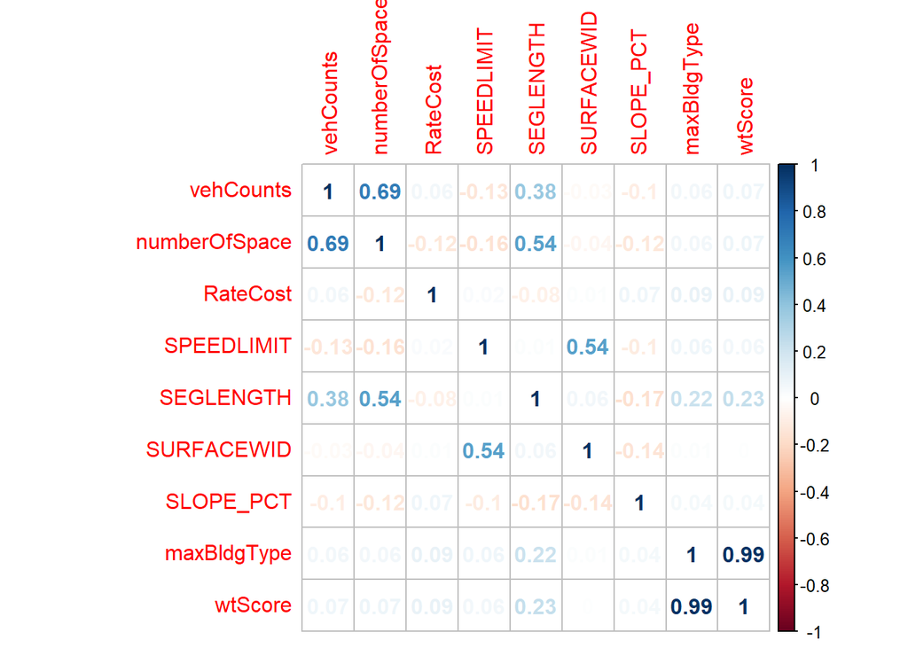

```r
#remove non-numeric variables
variablesCor<-select(variables, -Side,-DayPeriod,-AreaFull,-ARTDESCRIP,
                     -ONEWAY,-NATIONHWYS,-STREETTYPE,-CLASS_DESC,-bldgTypeCat)
M<-cor(variablesCor)
correlationPlot<-corrplot(M,method='number')
```

#### Current Conditions

Using several maps, we visualize the current conditions of the location and see what best characterizes the streets.

```r
#SetUp
mapTheme <- function(base_size = 12) {
  theme(
    text = element_text( color = "black"),
    plot.title = element_text(size = 14,colour = "black"),
    plot.subtitle=element_text(face="italic"),
    plot.caption=element_text(hjust=0),
    axis.ticks = element_blank(),
    panel.background = element_blank(),axis.title = element_blank(),
    axis.text = element_blank(),
    axis.title.x = element_blank(),
    axis.title.y = element_blank(),
    panel.grid.minor = element_blank(),
    panel.border = element_rect(colour = "black", fill=NA, size=2)
  )
}

baseformaps <- st_as_sf(parkRateStreets_noNA)
tracts2010 <- read_sf(dsn='C:/Users/angel/Dropbox/SPATIAL_ANALYSIS_FINAL/input_wgs84',layer='2010_US_Census_Tracts')
```

The map below shows where those ‘unofficial’ stalls are. It compares the locations where parking spaces were recorded and where there parking spaces were 0.

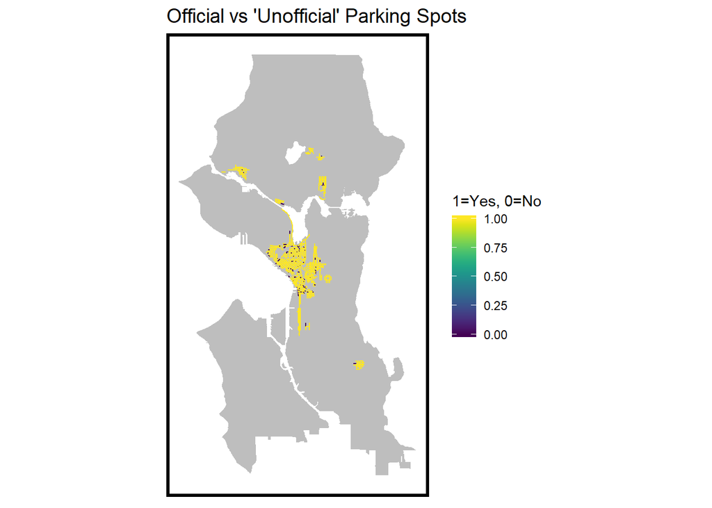

```r
# we look at where parking is permitted x not permitted
permissiontopark <- baseformaps
permissiontopark$permission <- ifelse(permissiontopark$numberOfSpace >=1, 1, 0)

# MAP permitted x not permitted
ggplot()+
  geom_sf(data = tracts2010, aes(), fill='grey', colour=NA)+
  geom_sf(data = permissiontopark, aes(color=permission))+
  scale_color_viridis()+
  labs (title = "Official vs 'Unofficial' Parking Spots", color = '1=Yes, 0=No')+
  mapTheme()
```

##### Average Occupancy by Times of Day

We want to explore how average occupancy vary by different time periods of the day. To do this, we break down the data into four different periods of the day - Morning, Afternoon, Evening, Night.

```r
# without places where parking is not permited
baseformaps2 <- filter(baseformaps, numberOfSpace >=1)

# maps per period

# Using the summary() command we checked the frequency of the rations and determined where to remove outliers for purposes of better visualization.
baseformaps4 <- filter(baseformaps2, avgOcc < 3.5)

Morning <- filter(baseformaps4, DayPeriod == 'Morning')
Afternoon <- filter(baseformaps4, DayPeriod == 'Afternoon')
Evening <- filter(baseformaps4, DayPeriod == 'Evening')
Night <- filter(baseformaps4, DayPeriod == 'Night')
```

Then, we plot each period of the day separately.

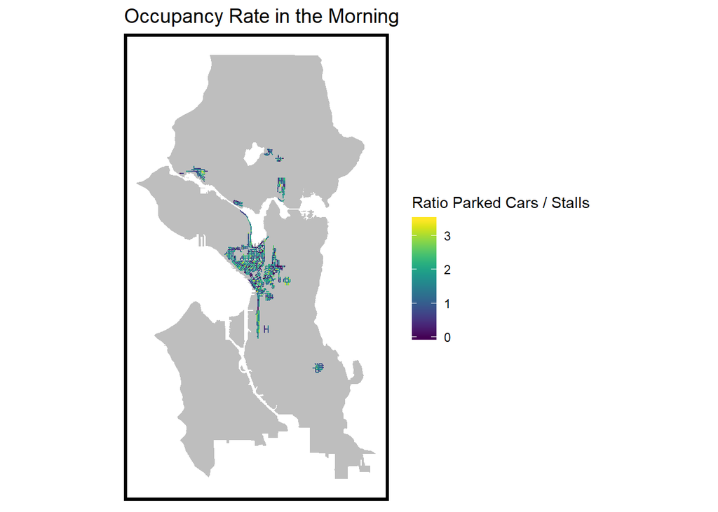

```r
# Morning
ggplot()+
  geom_sf(data = tracts2010, aes(), fill='grey', colour=NA)+
  geom_sf(data = Morning, aes(color=avgOcc))+
  scale_color_viridis()+
  labs (title = 'Occupancy Rate in the Morning', color = 'Ratio Parked Cars / Stalls')+
  mapTheme()
```

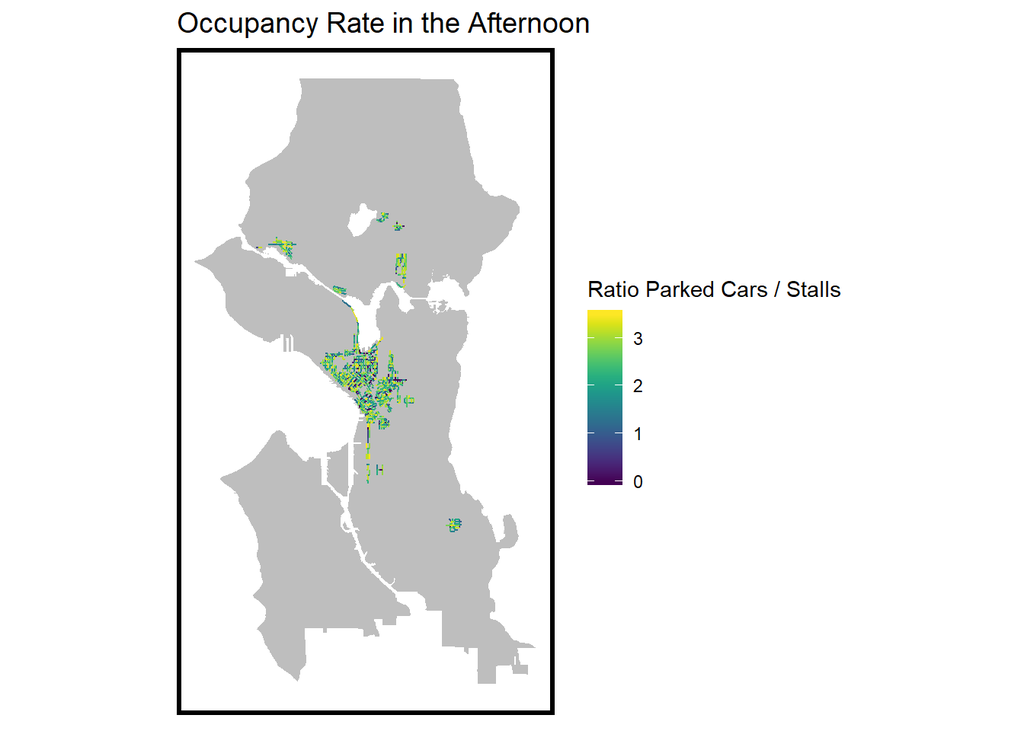

```r
# Afternoon
ggplot()+
  geom_sf(data = tracts2010, aes(), fill='grey', colour=NA)+
  geom_sf(data = Afternoon, aes(color=avgOcc))+
  scale_color_viridis()+
  labs (title = 'Occupancy Rate in the Afternoon', color = 'Ratio Parked Cars / Stalls')+
  mapTheme()
```

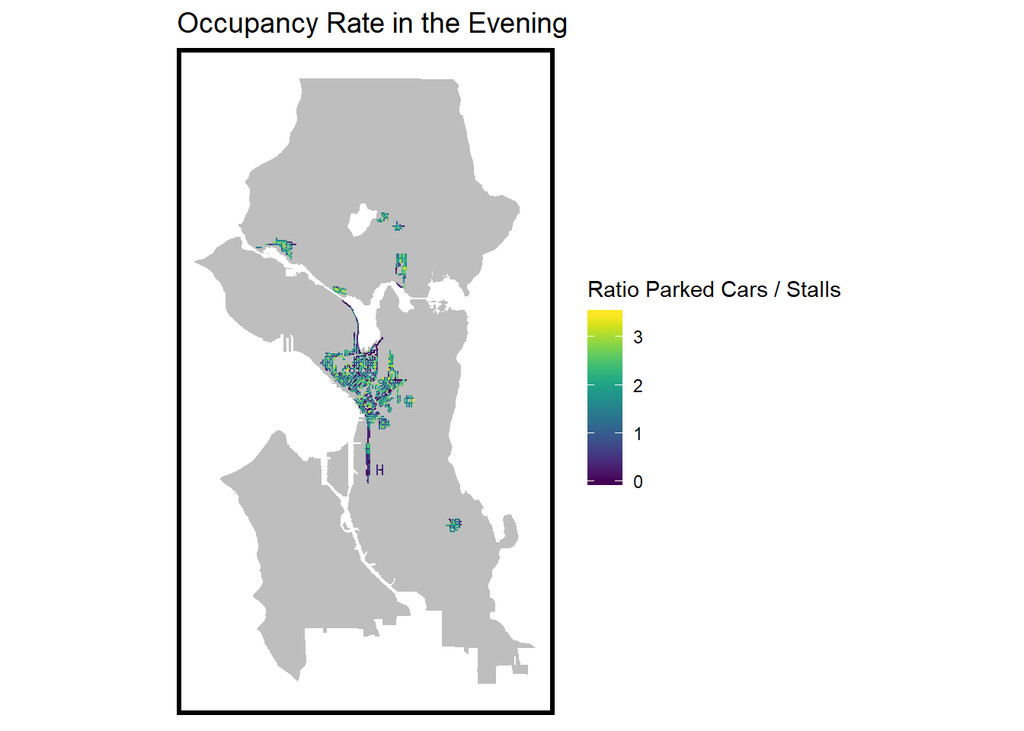

```r
# Evening
ggplot()+
  geom_sf(data = tracts2010, aes(), fill='grey', colour=NA)+
  geom_sf(data = Evening, aes(color=avgOcc))+
  scale_color_viridis()+
  labs (title = 'Occupancy Rate in the Evening', color = 'Ratio Parked Cars / Stalls')+
  mapTheme()
```

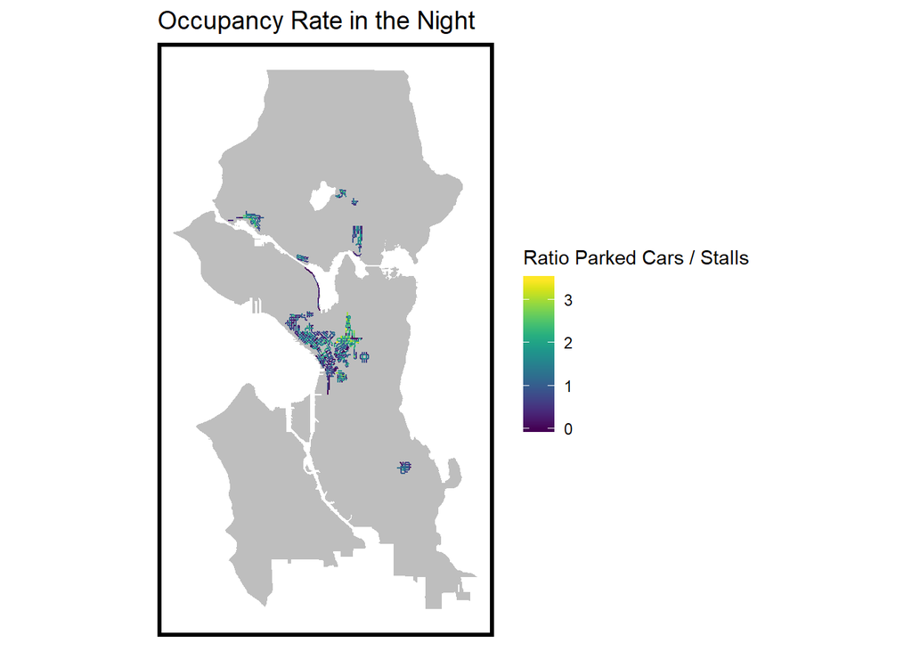

```r
# Night
ggplot()+
  geom_sf(data = tracts2010, aes(), fill='grey', colour=NA)+
  geom_sf(data = Night, aes(color=avgOcc))+
  scale_color_viridis()+
  labs (title = 'Occupancy Rate in the Night', color = 'Ratio Parked Cars / Stalls')+
  mapTheme()
```

We observe that occupancy rates vary by different time periods of the day. In the morning, occupany is predominantly low, as shown by the darker colors. In the afternoon, occupany is high all throughout the street segments on record. This makes sense as the area of study is mostly in downtown Seattle, where we would expect a lot of activity to occur. The occupancy rate drops in the evening time - we interpret this as most people leave the downtown area back to their homes. At night, occupancy drops even further, possibly reflective of most people being home and not in stores and offices.

##### Street Parking Rates by Times of Day

Next, we observe the variation of street parking rates. Seattle uses dynamic pricing for street parking. Based on the occupancy patterns previously discussed, we would expect parking rates to respod to this surge in afternoon parking.

Again, we filter by period of the day and explore the rates corresponding to these periods.

```r
baseformaps5 <- baseformaps2

MorningRate <- filter(baseformaps5, DayPeriod == 'Morning')
AfternoonRate <- filter(baseformaps5, DayPeriod == 'Afternoon')
EveningRate <- filter(baseformaps5, DayPeriod == 'Evening')
```

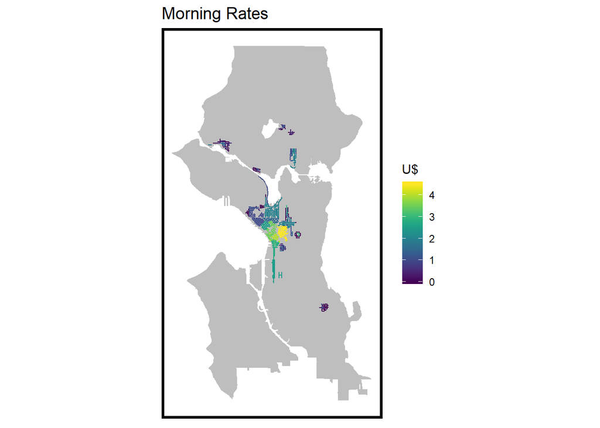

```r
# morning
ggplot()+
  geom_sf(data = tracts2010, aes(), fill='grey', colour=NA)+
  geom_sf(data = MorningRate, aes(color = MorningRate$RateCost), show.legend = T)+
  scale_color_viridis()+
  labs (title = 'Morning Rates', color = 'U$')+
  mapTheme()
```

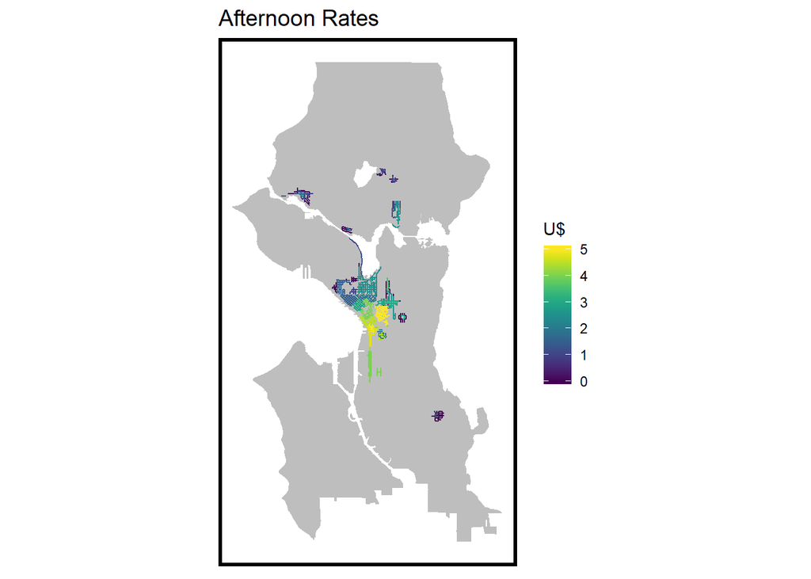

```r
# Afternoon
ggplot()+
  geom_sf(data = tracts2010, aes(), fill='grey', colour=NA)+
  geom_sf(data = AfternoonRate, aes(color = AfternoonRate$RateCost), show.legend = T)+
  scale_color_viridis()+
  labs (title = 'Afternoon Rates', color = 'U$')+
  mapTheme()
```

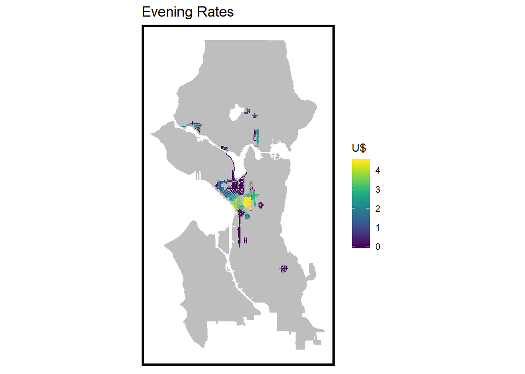

```r
# Evening
ggplot()+
  geom_sf(data = tracts2010, aes(), fill='grey', colour=NA)+
  geom_sf(data = EveningRate, aes(color = EveningRate$RateCost), show.legend = T)+
  scale_color_viridis()+
  labs (title = 'Evening Rates', color = 'U$')+
  mapTheme()
```

Given the parking rates information for each year (parkingratesXX.csv), there is no paid parking at night. Thus, mapping out the parking rate at night would be insignificant since there would be no price variation and all streets would show $0.

```r
# Night - FREE PARKING \o/
```

An interesting observation that can be made is that during the Afternoon period, parking occupancy was high all throughout. Parking costs, were higher during the afternoon period than the morning and evening. This means that despite the higher costs, people were still parking all throughout the downtown area.

##### Weight Scores

Finally, we map the weight scores given in each street segment. Remembering that these scores were based on the surrounding building types, we want to see the land use patterns.

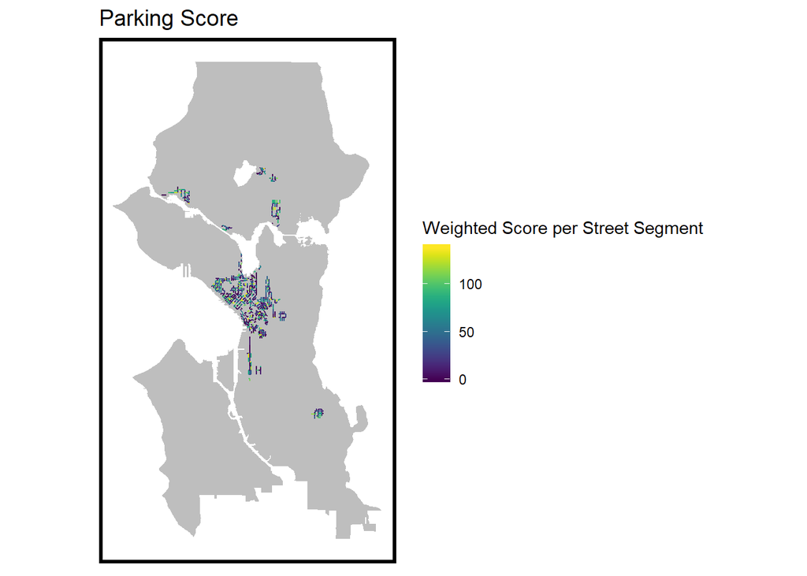

```r
# weighted score

##summary(baseformaps2$wtScore)
pkgscore <- filter(baseformaps2, wtScore <= 138)

ggplot()+
  geom_sf(data = tracts2010, aes(), fill='grey', colour=NA)+
  geom_sf(data = pkgscore, aes(color = pkgscore$wtScore), show.legend = T)+
  scale_color_viridis()+
  labs (title = 'Parking Score', color = 'Weighted Score per Street Segment')+
  mapTheme()
```

## 4. OLS Regression Model

#### 4.1 Kitchen Sink Model

We used occupancy ratio as our dependent variable, thus, we have built a linear model. We started it as a “Kitchen Sink” model - including every variable from out main data, which we believed to significantly influence our dependent variable.

```r
#Set Up
options(scipen = 999)
epsg <- 4326 #set projection for all spatial data
```

We partitioned our final dataset into *train* and *test* subsets, where 75% of the data is *train* and 25% of the data is *test*. We use the *train* dataset to train our model and later apply the final model into the *test* data, where we will predict our average Occupancy rate on unseen data.

```r
finalData<-parkingStNoZero
set.seed(336)
trainIndex <- createDataPartition(finalData$avgOcc, p=.75, list = FALSE, times = 1)
train <- finalData[ trainIndex,]
test  <- finalData[-trainIndex,]
```

We run the Kitchen Sink model, which includes all the initial predictors in the dataset.

```r
#Kitchen Sink Model
set.seed(125)

regParkingOccupancy <- lm(avgOcc ~ Side + DayPeriod + AreaFull + vehCounts + numberOfSpace +
                                   RateCost + ARTDESCRIP + SPEEDLIMIT + ONEWAY + SEGLENGTH +
                                   SURFACEWID + NATIONHWYS + STREETTYPE + SLOPE_PCT +
                                   CLASS_DESC + maxBldgType + bldgTypeCat +
                                   wtScore, data = train)
summary(regParkingOccupancy)
```

```
##
## Call:
## lm(formula = avgOcc ~ Side + DayPeriod + AreaFull + vehCounts +
##     numberOfSpace + RateCost + ARTDESCRIP + SPEEDLIMIT + ONEWAY +
##     SEGLENGTH + SURFACEWID + NATIONHWYS + STREETTYPE + SLOPE_PCT +
##     CLASS_DESC + maxBldgType + bldgTypeCat + wtScore, data = train)
##
## Residuals:
##      Min       1Q   Median       3Q      Max
## -17.5043  -0.3865  -0.0195   0.3309  15.7191
##
## Coefficients:
##                                                Estimate  Std. Error
## (Intercept)                                  4.26196385  0.62338315
## SideE                                       -0.29059739  0.49290549
## SideN                                       -0.28754052  0.49284222
## SideNE                                      -0.26452898  0.49359235
## SideNW                                      -0.23715869  0.49386593
## SideS                                       -0.31503195  0.49283161
## SideSE                                      -0.28281886  0.49377163
## SideSW                                      -0.21950926  0.49356924
## SideW                                       -0.26343430  0.49292299
## DayPeriodEvening                            -0.49660217  0.01839498
## DayPeriodMorning                            -0.67995015  0.01797845
## DayPeriodNight                              -0.73835375  0.02842834
## AreaFullBallard Core                         0.09014094  0.08875257
## AreaFullBallard Edge                         0.06266714  0.07799232
## AreaFullBallard Locks                        0.83396644  0.25448122
## AreaFullBallard Locks Summer                -0.51574672  0.20261546
## AreaFullBallard Unpaid                       0.15793924  0.08938832
## AreaFullBelltown North                      -2.10060539  0.24061636
## AreaFullBelltown South                      -2.12077447  0.24154290
## AreaFullCapitol Hill                        -0.22384648  0.59945343
## AreaFullCapitol Hill North                   0.15459435  0.08490094
## AreaFullCapitol Hill South                   0.10006873  0.07942755
## AreaFullCapitol Hill Unpaid                  0.23229244  0.09562793
## AreaFullCherry Hill                          0.10372880  0.17739795
## AreaFullCherry Hill Unpaid                   0.15475123  0.15177869
## AreaFullChinatown-ID Core                   -1.71679087  0.24379385
## AreaFullChinatown-ID Edge                   -1.68301294  0.24276814
```

[output cut: 254 more lines]

```
## CLASS_DESCResidential/Commercial            ***
## CLASS_DESCSingle Family
## maxBldgType                                 *
## bldgTypeCatIndustrial
## bldgTypeCatInstitutional
## bldgTypeCatMultifamily
## bldgTypeCatNoNearest                        ***
## bldgTypeCatSingleFamily                     *
## wtScore                                     *
## ---
## Signif. codes:  0 '***' 0.001 '**' 0.01 '*' 0.05 '.' 0.1 ' ' 1
##
## Residual standard error: 0.8415 on 18963 degrees of freedom
## Multiple R-squared:  0.6103, Adjusted R-squared:  0.6083
## F-statistic: 312.6 on 95 and 18963 DF,  p-value: < 0.00000000000000022
```

We played with different variable combinations and eliminated those considered insignificant. This was based on looking at the p-value (*p-value*<0.05). For some predictors, such as the neighborhood areas - a categorical predictor type - the significance value varied by different dummy variables. In cases like these, we kept this variable.

We created our final model and called it *Reg1*.

```r
reg1 <- lm(avgOcc ~ DayPeriod +
                    AreaFull +
                    vehCounts +
                    numberOfSpace +
                    RateCost +
                    ARTDESCRIP +
                    SEGLENGTH +
                    STREETTYPE +
                    CLASS_DESC +
                    maxBldgType +
                    wtScore,
                  data = train)
summary(reg1)
```

```
##
## Call:
## lm(formula = avgOcc ~ DayPeriod + AreaFull + vehCounts + numberOfSpace +
##     RateCost + ARTDESCRIP + SEGLENGTH + STREETTYPE + CLASS_DESC +
##     maxBldgType + wtScore, data = train)
##
## Residuals:
##      Min       1Q   Median       3Q      Max
## -17.7037  -0.3876  -0.0174   0.3311  15.7895
##
## Coefficients:
##                                                Estimate  Std. Error
## (Intercept)                                  4.05250993  0.37044310
## DayPeriodEvening                            -0.49681938  0.01840332
## DayPeriodMorning                            -0.67975801  0.01798434
## DayPeriodNight                              -0.73843277  0.02843726
## AreaFullBallard Core                         0.12298216  0.08393555
## AreaFullBallard Edge                         0.08192400  0.07368282
## AreaFullBallard Locks                        0.76881485  0.25116182
## AreaFullBallard Locks Summer                -0.58060995  0.19817298
## AreaFullBallard Unpaid                       0.18874394  0.08490304
## AreaFullBelltown North                      -2.07600249  0.23955362
## AreaFullBelltown South                      -2.09848841  0.24038876
## AreaFullCapitol Hill                        -0.19596112  0.59916601
## AreaFullCapitol Hill North                   0.16196248  0.08456811
## AreaFullCapitol Hill South                   0.09797544  0.07863213
## AreaFullCapitol Hill Unpaid                  0.23108222  0.09496193
## AreaFullCherry Hill                          0.05984948  0.17630429
## AreaFullCherry Hill Unpaid                   0.08831644  0.14957753
## AreaFullChinatown-ID Core                   -1.70923973  0.24244858
## AreaFullChinatown-ID Edge                   -1.68986010  0.24140604
## AreaFullColumbia City                        0.09417133  0.10721972
## AreaFullColumbia City Unpaid                -0.06978693  0.09784564
## AreaFullCommercial Core Financial           -2.16681240  0.24260970
## AreaFullCommercial Core Retail              -2.20638812  0.24058770
## AreaFullCommercial Core Waterfront          -2.04234659  0.24253239
## AreaFullDenny Triangle North                -2.09793130  0.24079189
## AreaFullDenny Triangle South                -2.12725736  0.24482614
## AreaFullDexter Unpaid                        0.22730906  0.21941106
## AreaFullFirst Hill                          -0.12769151  0.06667851
```

[output cut: 199 more lines]

```
## CLASS_DESCMajor Institutions                .
## CLASS_DESCManufacturing/Industrial          ***
## CLASS_DESCMaster Planned Community
## CLASS_DESCMulti-Family
## CLASS_DESCNeighborhood/Commercial           **
## CLASS_DESCResidential/Commercial            ***
## CLASS_DESCSingle Family                     .
## maxBldgType                                 *
## wtScore                                     .
## ---
## Signif. codes:  0 '***' 0.001 '**' 0.01 '*' 0.05 '.' 0.1 ' ' 1
##
## Residual standard error: 0.842 on 18981 degrees of freedom
## Multiple R-squared:  0.6094, Adjusted R-squared:  0.6079
## F-statistic: 384.7 on 77 and 18981 DF,  p-value: < 0.00000000000000022
```

The plot below shows how our predictions compare to the actual observed values from the *train* set. A perfectly accurate model would show that the points lie along the red line. However, the best fit line (shown in blue) shows that our predictions were not as accurate. It shows that our predictions were mostly below the observed data. One reason could be that most of the observations are on places with intensive commercial and institutional activities, and we do not compute the height of the buildings in each area. For example, a tall office and commercial building in the downtown area generates significant demand for parking, but that is rated in our model the same way we rate a gas station/convenience store in a mixes zone, because we lack more information about the characteristics of the building.

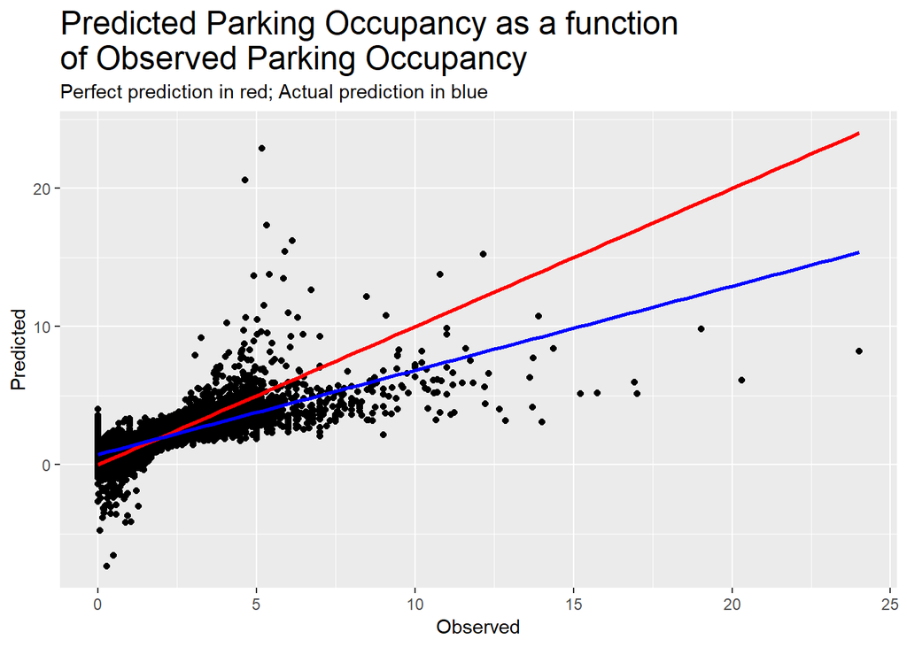

```r
#regression Predicted Values
regDF<-cbind(train$avgOcc,reg1$fitted.values)
colnames(regDF)<-c("Observed","Predicted")
regDF<-as.data.frame(regDF)

#plotting predicted and observed ):
ggplot() +
  geom_point(data=regDF, aes(Observed, Predicted)) +
  stat_smooth(data=regDF, aes(Observed, Observed), method = "lm", se = FALSE, size = 1, colour="red") +
  stat_smooth(data=regDF, aes(Observed, Predicted), method = "lm", se = FALSE, size = 1, colour="blue") +
  labs(title="Predicted Parking Occupancy as a function\nof Observed Parking Occupancy",
       subtitle="Perfect prediction in red; Actual prediction in blue") +
  theme(plot.title = element_text(size = 18,colour = "black"))
```

#### 4.2 Model Validation

To evaluate the accuracy of our model, we used cross validation of 50 folds using out *train* data.

```r
#100 folds for cross validation
fitControl <- trainControl(method = "cv", number = 50)
set.seed(825)

lmFit <- train(avgOcc ~ DayPeriod +
                 AreaFull +
                 vehCounts +
                 numberOfSpace +
                 RateCost +
                 ARTDESCRIP +
                 SEGLENGTH +
                 STREETTYPE +
                 CLASS_DESC +
                 maxBldgType +
                 wtScore,
               data = train, method = "lm", trControl = fitControl)
lmFit
```

```
## Linear Regression
##
## 19059 samples
##    11 predictor
##
## No pre-processing
## Resampling: Cross-Validated (50 fold)
## Summary of sample sizes: 18678, 18676, 18679, 18679, 18678, 18677, ...
## Resampling results:
##
##   RMSE       Rsquared   MAE
##   0.8319621  0.6320715  0.5170111
##
## Tuning parameter 'intercept' was held constant at a value of TRUE
```

We also calculated the Mean Absolute Error (MAE) and the Mean Absoulte Percentage Error (MAPE) and compared it against the lmFit results as follows:

```r
#MAE
mean(abs(reg1$fitted.values - train$avgOcc))
```

```
## [1] 0.5143483
```

```r
#MAPE
mean(abs(reg1$fitted.values - train$avgOcc) / train$avgOcc)
```

```
## [1] Inf
```

Our model results are summarized below:

[output not shown]

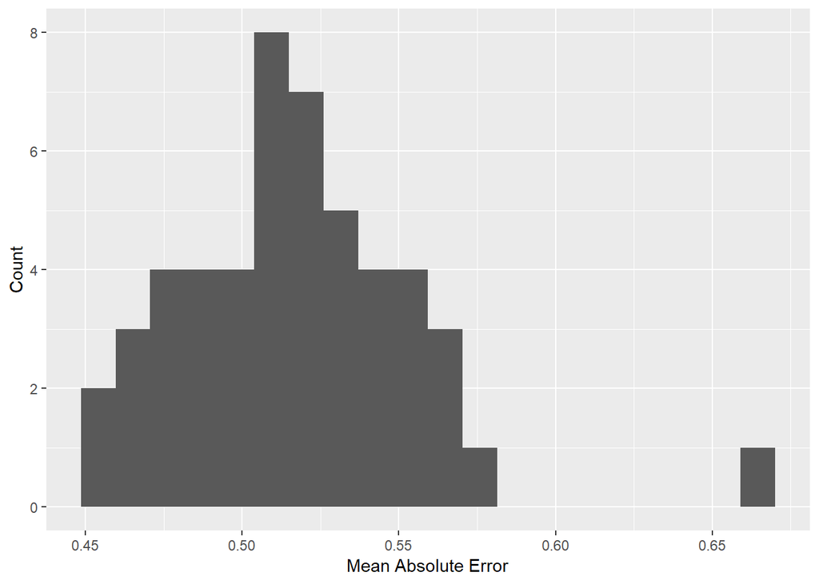

```r
ggplot(as.data.frame(lmFit$resample), aes(MAE)) +
  geom_histogram(bins=20) +
  labs(x="Mean Absolute Error",
       y="Count")
```

Even though our final model R2 decreased slightly (compared to 0.6104 from the Kitchen Sink Model) and our RMSE increased slightly (compared to 0.8411 from the Kitchen Sink), we prefer this model because we removed insignificant predictors and avoid overfitting the model.

It is hard to say that our model is generalizable because it was mostly trained on and tested on observations that mostly come from the downtown area of the city. Hence, if this model were to be applied in another region outside of Seattle, it is highly likely that the predictions be off. Hence, this model is more accurate to the street segments of Downtown Seattle.

#### Testing the Predictive Power of Our Model in Unseen Data

After fitting our final model, we tested the predictive power of our model in unseen data - the *test* data. We predicted for the average parking occupancy rates in Seattle.

```r
#predict for test
regPred <- predict(reg1, test)
regPredValues <-
  data.frame(observedOccupancy = test$avgOcc,
             predictedOccupancy = regPred)
regPredValues <-
  regPredValues %>%
  mutate(error = predictedOccupancy - observedOccupancy) %>%
  mutate(absError = abs(predictedOccupancy - observedOccupancy)) %>%
  mutate(percentAbsError = abs(predictedOccupancy - observedOccupancy) / observedOccupancy)
mean(regPredValues$absError)
```

```
## [1] 0.5205989
```

Similar to the *train* data, we compared the predicted values for unseen data (*test* data) and comapred them against the actual values.

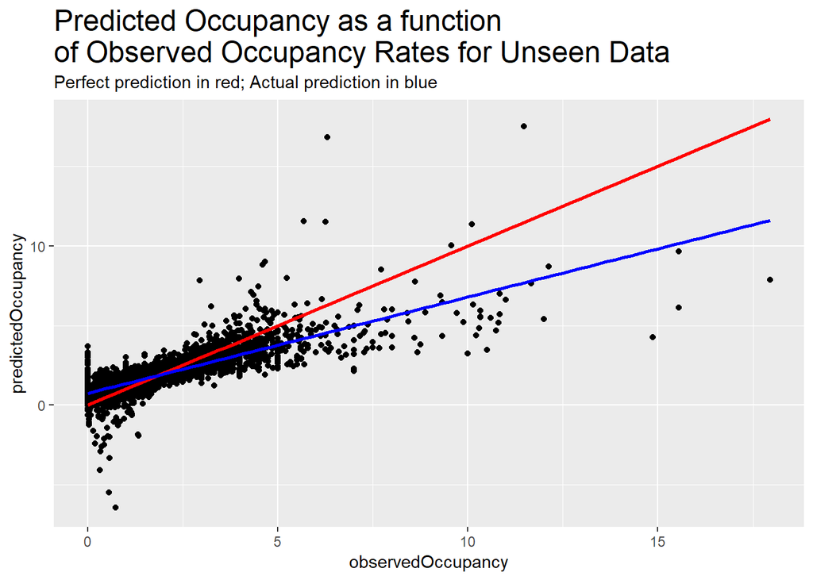

```r
ggplot() +
  geom_point(data=regPredValues, aes(observedOccupancy, predictedOccupancy)) +
  stat_smooth(data=regPredValues, aes(observedOccupancy, observedOccupancy), method = "lm", se = FALSE, size = 1, colour="red") +
  stat_smooth(data=regPredValues, aes(observedOccupancy, predictedOccupancy), method = "lm", se = FALSE, size = 1, colour="blue") +
  labs(title="Predicted Occupancy as a function\nof Observed Occupancy Rates for Unseen Data",
       subtitle="Perfect prediction in red; Actual prediction in blue") +
  theme(plot.title = element_text(size = 18,colour = "black"))
```

### Testing for a Change in Neighborhood Characteristic

To investigate if our model would be useful in an app the way we described in the beginning of this document, we made a copy of our testset and changed the neighborhood characteristic. We changed every residential (single family and multifamily) street segment to neighborhood/commercial zoning (to emulate the way our app would work for planners).

We began by making a copy of the *test* data and a copy of the CLASS_DESC column (called CLASS_COPY), which describes the type of zone representing each street segment. This is the column where we change the zoning type - for the purposes of demonstration, we use the example of changing **“Multi-Family”** and **“Single Family”** zones into **“Neighborhood/Commercial”** zones.

Using the table() command, we check to make sure we are correctly changing the factors. For example, we have 544 Multi-Family, 38 Single Family, and 1565 Neighborhood/Commercial observations. After changing the former two factors (544+38) we should result in a total of 2147 Neighborhood/Commercial observations (from 544+38+1565).

```r
#create copy of test with changed CLASS_DESC (change of zoning)
# Multi-Family and Single Family to Neighborhood/Commercial
test2<-test
table(test2$CLASS_DESC)
```

```
##
##                 Downtown       Major Institutions Manufacturing/Industrial
##                     2425                      390                      168
## Master Planned Community             Multi-Family  Neighborhood/Commercial
##                        2                      544                     1565
##   Residential/Commercial            Single Family
##                     1219                       38
```

```r
 #Multi-Family (544) and Single Family (38)
 #Neighborhood/Commercial (1565)
test2$CLASS_COPY<-test2$CLASS_DESC
test2$CLASS_COPY[test2$CLASS_COPY=='Multi-Family']<-'Neighborhood/Commercial'
test2$CLASS_COPY[test2$CLASS_COPY=='Single Family']<-'Neighborhood/Commercial'

#check correct change (Neighborhood/Commercial - 2147)
sum(test2$CLASS_COPY=='Neighborhood/Commercial') #2147
```

```
## [1] 2147
```

We replace the old CLASS_DESC column with the new CLASS_COPY columns to reflect a similar dataframe structure as the previous one.

```r
#replace column
test3<-subset(test2[c(1:16,22,18:21)])
```

Because the column name was changed (CLASS_DESC to CLASS_COPY), we cannot call the same regression model as it will not idenfity the correct column name. To work around this, we created a copy of our model and only the changed variable column name so we can call test the data on a same model.

```r
train2<-train
colnames(train2)[17]<-'CLASS_COPY'
reg1_copy <- lm(avgOcc ~ DayPeriod +
             AreaFull +
             vehCounts +
             numberOfSpace +
             RateCost +
             ARTDESCRIP +
             SEGLENGTH +
             STREETTYPE +
             CLASS_COPY + #column with changed neighborhood characteristics
             maxBldgType +
             wtScore,
           data = train2)
```

We now repeat the same process, predicting for the average occupancy rate for test set with zonal change (Multi-Family and Single Family to Neighborhood/Commercial).

```r
#now predict for changed zone
regPredNew<-predict(reg1_copy,test3)
regPredNewValues<-
  data.frame(oldClass<-test$CLASS_DESC,
             newClass<-test3$CLASS_COPY,
             observedOccupancy = test$avgOcc,
             predictedOccupancy = regPred,
             newPredictions = regPredNew)

regPredNewValues<-
  regPredNewValues%>%
  mutate(error = predictedOccupancy - observedOccupancy) %>%
  mutate(absError = abs(predictedOccupancy - observedOccupancy)) %>%
  mutate(percentAbsError = abs(predictedOccupancy - observedOccupancy) / observedOccupancy)
mean(regPredValues$absError)
```

```
## [1] 0.5205989
```

We cannot compare the newly predicted values against observed, as we do not have the observed values for the changed classes. Instead, here we built a dataframe with old and new zoning classes (other zones kept the same), the observed occupancy ratio, the predicted occupancy in the regular testset, and the prediction with the changed zoning.

As previously explained in our feature engineering process, commercial were weighted higher than residential areas, justified by the idea that commercial places are attraction points, meaning that greater activity and movement of people (parking and leaving) increases the overall average of parking occupancy. This means that we would expect our new predictions to be higher.

To verify this, we created a “changed_obs” column to compare the newPredicitons with the previous predictions (before a neighborhood change was made).

```r
change_obs <- subset(regPredNewValues, oldClass....test.CLASS_DESC == "Single Family" |
                       oldClass....test.CLASS_DESC == "Multi-Family")
sum(change_obs$error)
```

```
## [1] 3.672207
```

```r
change_obs$change_error <- change_obs$newPredictions - change_obs$predictedOccupancy
change_obs$moreorless <- ifelse(change_obs$change_error>0, 1,0)

change_positive <- subset(change_obs, moreorless==1)
change_negative <- subset(change_obs, moreorless==0)

sum(change_positive$change_error)
```

```
## [1] 0
```

```r
sum(change_negative$change_error)
```

```
## [1] -79.9979
```

```r
mean(change_negative$change_error)
```

```
## [1] -0.1374534
```

Despite not having observed values for the changed classes, we were surprised to verify that the new predictions had a lower occupancy ratio than the values on the normal testset. This lower prediction could also be due to chaning the CLASS_DESC column (from the Seattle Zoning Classifications) and not the weight score column (which was created from the Building Permits data). This indicates that our model needs further work in the way it interprets zoning as a variable.

## 5. Discussion

Our analysis provides occupancy ratios per street segment. When we started to look at the data and how to approach the spatial scale, we have imagined many ways to summarize the parking data. Census blocks looked as an adequate geographical unit to aggregate occupancy ratios, because we assumed people are willing to do short walks if that helps them finding a parking spot. However, we realized that street segments provide unique insight to the model, because at this scale we can account for features like street direction or type of street (major / collector / local street).

Having a prediction of occupancy ratio correlated to many different aspects of the built environment allow us to understand how those variables modify our model and, therefore, to build afterwards an application in which different settings of a parcel, of block, or area, could be adjusted according to future developments or zoning changes. That is how our model would contribute to the kind of tool we are suggesting for planners.

## 6. Limitations and next steps for improvement

Based on the results and analyses of our model, we can summarize some problems with the data wrangling that prevented us from building a better and stronger predictive model:

- The data information is inconsistent, which prevented us to add variables that would increase our predictive power, such as whether the observation was in a week day or weekend, or in which season the observation occurred.
- Weather data would probably be a good feature to include in the model, since people tend to drive, rather than walk or bike, in rainy or cold days. Unfortunately, this data is behind a paywall.
- For analyzing the build environment, we have worked with building permits, and the zoning code. We understand that urban density plays a major role in creating more demand for parking spaces. We have searched for data about verticality of the buildings, but unfortunately, we haven’t found such data.

### References

2010 Census Tracts for Seattle. Available at: https://data.seattle.gov/Land-Base/2010-US-Census-Tracts/brir-43d4 Building Permits: Available at: https://data.seattle.gov/Permitting/Building-Permits/76t5-zqzr City of Seattle Zoning. Available at: https://data.seattle.gov/dataset/City-Of-Seattle-Zoning/2hat-teay Seattle Streets. Available at: https://data.seattle.gov/Transportation/Seattle-Streets/jc8u-fewc Annual Parking Study Data. Available at: https://data.seattle.gov/Transportation/Annual-Parking-Study-Data/7jzm-ucez Seattle Parking Reports (2014-2018, for parking rates). Available at: https://www.seattle.gov/transportation/document-library/reports-and-studies

## Appendix

A.1 Cleaning Area names for consistency:

```r
#For observation areas were not found in the parking rates, they were omitted using NA.
parking4$Area1[parking4$Area1=='15th Avenue']<-NA
parking4$Area1[parking4$Area1=='Ballard - Weekday']<-'Ballard'
parking4$Area1[parking4$Area1=='Ballard Locks - Weekday (Spring)']<-'Ballard Locks Summer'
parking4$Area1[parking4$Area1=='Ballard Locks - Weekday (Summer)']<-'Ballard Locks Summer'
parking4$Area1[parking4$Area1=='Ballard Locks Spring']<-'Ballard Locks Summer'
parking4$Area1[parking4$Area1=='Ballard Locks Spring 2017']<-'Ballard Locks Summer'
parking4$Area1[parking4$Area1=='Ballard Locks summer']<-'Ballard Locks Summer'

parking4$Area1[parking4$Area1=='Belltown - Weekday']<-'Belltown'
parking4$Area1[parking4$Area1=='Capitol Hill - Weekday']<-'Capitol Hill'
parking4$Area1[parking4$Area1=='Cherry Hill - Weekday']<-'Cherry Hill'
parking4$Area1[parking4$Area1=='Chinatown']<-'Chinatown ID'
parking4$Area1[parking4$Area1=='Chinatown ID 2017']<-'Chinatown ID'
parking4$Area1[parking4$Area1=='Chinatown/ID']<-'Chinatown ID'
parking4$Area1[parking4$Area1=='Chinatown/ID - Weekday']<-'Chinatown ID'

parking4$Area1[parking4$Area1=='Commercial Core - Financial']<-'Commercial Core Financial'
parking4$Area1[parking4$Area1=='Commercial Core - Retail']<-'Commercial Core Retail'
parking4$Area1[parking4$Area1=='Commercial Core - Waterfront']<-'Commercial Core Waterfront'
parking4$Area1[parking4$Area1=='Commercial Core - Weekday']<-'Commercial Core'

#checkpoint
parking4$Area1[parking4$Area1=='Denny Triangle - Weekday']<-'Denny Triangle'
parking4$Area1[parking4$Area1=='Denny Triangle North - 2017']<-'Denny Triangle North'
parking4$Area1[parking4$Area1=='Denny Triangle South - 2017']<-'Denny Triangle South'

parking4$Area1[parking4$Area1=='First Hill - Weekday']<-'First Hill'
parking4$Area1[parking4$Area1=='Fremont - Weekday']<-'Fremont'
parking4$Area1[parking4$Area1=='Green Lake - Weekday']<-'Green Lake'
parking4$Area1[parking4$Area1=='Greenlake']<-'Green Lake'
parking4$Area1[parking4$Area1=='Lake City']<-NA
parking4$Area1[parking4$Area1=='Little Saigon - Sunday']<-NA
parking4$Area1[parking4$Area1=='Little Saigon - Weekday']<-NA

parking4$Area1[parking4$Area1=='Pike-Pine - Weekday']<-'Pike-Pine'
parking4$Area1[parking4$Area1=='Pioneer Square - Weekday']<-'Pioneer Square'
parking4$Area1[parking4$Area1=='Pioneer Square 2017']<-'Pioneer Square'

parking4$Area1[parking4$Area1=='Roosevelt - Weekday']<-'Roosevelt'
parking4$Area1[parking4$Area1=='SODO']<-'Pioneer Square Edge'

parking4$Area1[parking4$Area1=='South Lake Union - Weekday']<-'South Lake Union'
parking4$Area1[parking4$Area1=='University District - Weekday']<-'University District'
parking4$Area1[parking4$Area1=='Uptown - Weekday']<-'Uptown'

parking4$Area1[parking4$Area1=='Uptown Triangle - Weekday']<-'Uptown Triangle'
parking4$Area1[parking4$Area1=='Westlake']<-'Westlake Ave N'
parking4$Area1[parking4$Area1=='Westlake - Weekday']<-'Westlake Ave N'
parking4$Area1[parking4$Area1=='West Seattle']<-NA

#make copy before combining sundays and events into same area for graphs later on
parking4$Area1Copy<-parking4$Area1

parking4$Area1[parking4$Area1=='Chinatown/ID - Event']<-'Chinatown ID'
parking4$Area1[parking4$Area1=='Chinatown/ID - Sunday']<-'Chinatown ID'
parking4$Area1[parking4$Area1=='Commercial Core - Event Day']<-'Commercial Core'
parking4$Area1[parking4$Area1=='Pioneer Square - Event Day']<-'Pioneer Square'
parking4$Area1[parking4$Area1=='Pioneer Square - Sunday']<-'Pioneer Square'
parking4$Area1[parking4$Area1=='Pioneer Square - Event Day']<-'Pioneer Square'
parking4$Area1[parking4$Area1=='Pioneer Square - Sunday']<-'Pioneer Square'
parking4$Area1[parking4$Area1=='Uptown - Sunday']<-'Uptown'
parking4$Area1[parking4$Area1=='Uptown - Sunday']<-'Uptown'
```

A.2 Cleaning Subareas names for consistency:

```r
parking6$Area3<-ifelse(parking6$Area2=='Belltown - Weekday (North Subarea)','Belltown North',parking6$Area3)
parking6$Area3<-ifelse(parking6$Area2=='Belltown - Weekday (South Subarea)','Belltown South',parking6$Area3)
parking6$Area3<-ifelse(parking6$Area2=='Belltown (North Subarea)','Belltown North',parking6$Area3)
parking6$Area3<-ifelse(parking6$Area2=='Belltown (South Subarea)','Belltown South',parking6$Area3)

parking6$Area3<-ifelse(parking6$Area2=='Capitol Hill - Weekday (  Subarea)','Capitol Hill',parking6$Area3)
parking6$Area3<-ifelse(parking6$Area2=='Capitol Hill - Weekday (North Subarea)','Capitol Hill North',parking6$Area3)
parking6$Area3<-ifelse(parking6$Area2=='Capitol Hill - Weekday (South Subarea)','Capitol Hill South',parking6$Area3)
parking6$Area3<-ifelse(parking6$Area2=='Capitol Hill - Weekday (Unpaid Subarea)','Capitol Hill Unpaid',parking6$Area3)
parking6$Area3<-ifelse(parking6$Area2=='Capitol Hill (North Subarea)','Capitol Hill North',parking6$Area3)
parking6$Area3<-ifelse(parking6$Area2=='Capitol Hill (South Subarea)','Capitol Hill South',parking6$Area3)
parking6$Area3<-ifelse(parking6$Area2=='Capitol Hill (Unpaid Subarea)','Capitol Hill Unpaid',parking6$Area3)

parking6$Area3<-ifelse(parking6$Area2=='Cherry Hill - Weekday (Paid Subarea)','Cherry Hill',parking6$Area3)
parking6$Area3<-ifelse(parking6$Area2=='Cherry Hill - Weekday (Unpaid Subarea)','Cherry Hill Unpaid',parking6$Area3)
parking6$Area3<-ifelse(parking6$Area2=='Cherry Hill (Paid Subarea)','Cherry Hill',parking6$Area3)
parking6$Area3<-ifelse(parking6$Area2=='Cherry Hill (PAID Subarea)','Cherry Hill',parking6$Area3)
parking6$Area3<-ifelse(parking6$Area2=='Cherry Hill (Unpaid Subarea)','Cherry Hill Unpaid',parking6$Area3)
parking6$Area3<-ifelse(parking6$Area2=='Cherry Hill (UNPAID Subarea)','Cherry Hill Unpaid',parking6$Area3)

parking6$Area3<-ifelse(parking6$Area2=='Chinatown ID 2017 (Core Subarea)','Chinatown-ID Core',parking6$Area3)
parking6$Area3<-ifelse(parking6$Area2=='Chinatown ID 2017 (Edge Subarea)','Chinatown-ID Edge',parking6$Area3)
parking6$Area3<-ifelse(parking6$Area2=='Chinatown/ID - Event (Core Subarea)','Chinatown-ID Core',parking6$Area3)
parking6$Area3<-ifelse(parking6$Area2=='Chinatown/ID - Event (Periphery Subarea)','Chinatown-ID Edge',parking6$Area3)
parking6$Area3<-ifelse(parking6$Area2=='Chinatown/ID - Sunday (Core Subarea)','Chinatown-ID Core',parking6$Area3)
parking6$Area3<-ifelse(parking6$Area2=='Chinatown/ID - Sunday (Periphery Subarea)','Chinatown-ID Edge',parking6$Area3)
parking6$Area3<-ifelse(parking6$Area2=='Chinatown/ID - Weekday (Core Subarea)','Chinatown-ID Core',parking6$Area3)
parking6$Area3<-ifelse(parking6$Area2=='Chinatown/ID - Weekday (Periphery Subarea)','Chinatown-ID Edge',parking6$Area3)
parking6$Area3<-ifelse(parking6$Area2=='Chinatown/ID (Core Subarea)','Chinatown-ID Core',parking6$Area3)
parking6$Area3<-ifelse(parking6$Area2=='Chinatown/ID (Edge Subarea)','Chinatown-ID Edge',parking6$Area3)

parking6$Area3<-ifelse(parking6$Area2=='Columbia City (PAID Subarea)','Columbia City',parking6$Area3)
parking6$Area3<-ifelse(parking6$Area2=='Columbia City (UNPAID Subarea)','Columbia City Unpaid',parking6$Area3)

parking6$Area3<-ifelse(parking6$Area2=='Commercial Core - Event Day (Waterfront Subarea)','Commercial Core Waterfront',parking6$Area3)
parking6$Area3<-ifelse(parking6$Area2=='Commercial Core - Financial (Financial Subarea)','Commercial Core Financial',parking6$Area3)
parking6$Area3<-ifelse(parking6$Area2=='Commercial Core - Retail (Retail Subarea)','Commercial Core Retail',parking6$Area3)
parking6$Area3<-ifelse(parking6$Area2=='Commercial Core - Waterfront (Waterfront Subarea)','Commercial Core Waterfront',parking6$Area3)
parking6$Area3<-ifelse(parking6$Area2=='Commercial Core - Weekday (Financial Subarea)','Commercial Core Financial',parking6$Area3)
parking6$Area3<-ifelse(parking6$Area2=='Commercial Core - Weekday (Retail Subarea)','Commercial Core Retail',parking6$Area3)
parking6$Area3<-ifelse(parking6$Area2=='Commercial Core - Weekday (Waterfront Subarea)','Commercial Core Waterfront',parking6$Area3)
parking6$Area3<-ifelse(parking6$Area2=='Commercial Core (Financial Subarea)','Commercial Core Financial',parking6$Area3)
parking6$Area3<-ifelse(parking6$Area2=='Commercial Core (Retail Subarea)','Commercial Core Retail',parking6$Area3)
parking6$Area3<-ifelse(parking6$Area2=='Commercial Core (Waterfront Subarea)','Commercial Core Waterfront',parking6$Area3)
parking6$Area3<-ifelse(parking6$Area2=='Commercial Core Financial (Financial Subarea)','Commercial Core Financial',parking6$Area3)
parking6$Area3<-ifelse(parking6$Area2=='Commercial Core Retail (Retail Subarea)','Commercial Core Retail',parking6$Area3)
parking6$Area3<-ifelse(parking6$Area2=='Commercial Core Waterfront (Waterfront Subarea)','Commercial Core Waterfront',parking6$Area3)

parking6$Area3<-ifelse(parking6$Area2=='Denny Triangle - Weekday (North Subarea)','Denny Triangle North',parking6$Area3)
parking6$Area3<-ifelse(parking6$Area2=='Denny Triangle - Weekday (South Subarea)','Denny Triangle South',parking6$Area3)
parking6$Area3<-ifelse(parking6$Area2=='Denny Triangle (North Subarea)','Denny Triangle North',parking6$Area3)
parking6$Area3<-ifelse(parking6$Area2=='Denny Triangle (South Subarea)','Denny Triangle South',parking6$Area3)
parking6$Area3<-ifelse(parking6$Area2=='Denny Triangle North - 2017 (North Subarea)','Denny Triangle North',parking6$Area3)
parking6$Area3<-ifelse(parking6$Area2=='Denny Triangle South - 2017 (South Subarea)','Denny Triangle South',parking6$Area3)
parking6$Area3<-ifelse(parking6$Area2=='Denny Triangle North (PAID Subarea)','Denny Triangle North',parking6$Area3)
parking6$Area3<-ifelse(parking6$Area2=='Denny Triangle South (PAID Subarea)','Denny Triangle South',parking6$Area3)

parking6$Area3<-ifelse(parking6$Area2=='Dexter (Unpaid Subarea)','Dexter Unpaid',parking6$Area3)
parking6$Area3<-ifelse(parking6$Area2=='First Hill (Unpaid Subarea)','First Hill Unpaid',parking6$Area3)
parking6$Area3<-ifelse(parking6$Area2=='Fremont - Weekday (  Subarea)','Fremont',parking6$Area3)
parking6$Area3<-ifelse(parking6$Area2=='Fremont - Weekday (Paid Subarea)','Fremont',parking6$Area3)
parking6$Area3<-ifelse(parking6$Area2=='Fremont - Weekday (Unpaid Subarea)','Fremont Unpaid',parking6$Area3)
parking6$Area3<-ifelse(parking6$Area2=='Fremont (Paid Subarea)','Fremont',parking6$Area3)
parking6$Area3<-ifelse(parking6$Area2=='Fremont (Unpaid Subarea)','Fremont Unpaid',parking6$Area3)
parking6$Area3<-ifelse(parking6$Area2=='Fremont (PAID Subarea)','Fremont',parking6$Area3)
parking6$Area3<-ifelse(parking6$Area2=='Fremont (UNPAID Subarea)','Fremont Unpaid',parking6$Area3)
```

```r
parking6$Area3<-ifelse(parking6$Area2=='Green Lake - Weekday (Paid Subarea)','Green Lake',parking6$Area3)
parking6$Area3<-ifelse(parking6$Area2=='Green Lake - Weekday (Unpaid Subarea)','Green Lake Unpaid',parking6$Area3)
parking6$Area3<-ifelse(parking6$Area2=='Green Lake (Paid Subarea)','Green Lake',parking6$Area3)
parking6$Area3<-ifelse(parking6$Area2=='Green Lake (Unpaid Subarea)','Green Lake Unpaid',parking6$Area3)
parking6$Area3<-ifelse(parking6$Area2=='Greenlake (PAID Subarea)','Green Lake',parking6$Area3)
parking6$Area3<-ifelse(parking6$Area2=='Greenlake (UNPAID Subarea)','Green Lake Unpaid',parking6$Area3)

parking6$Area3<-ifelse(parking6$Area2=='Pike-Pine - Weekday (Paid Subarea)','Pike-Pine',parking6$Area3)
parking6$Area3<-ifelse(parking6$Area2=='Pike-Pine - Weekday (Unpaid Subarea)','Pike-Pine Unpaid',parking6$Area3)
parking6$Area3<-ifelse(parking6$Area2=='Pike-Pine (Paid Subarea)','Pike-Pine',parking6$Area3)
parking6$Area3<-ifelse(parking6$Area2=='Pike-Pine (Unpaid Subarea)','Pike-Pine Unpaid',parking6$Area3)

parking6$Area3<-ifelse(parking6$Area2=='Pioneer Square - Event Day (Core Subarea)','Pioneer Square Core',parking6$Area3)
parking6$Area3<-ifelse(parking6$Area2=='Pioneer Square - Event Day (Periphery Subarea)','Pioneer Square Edge',parking6$Area3)
parking6$Area3<-ifelse(parking6$Area2=='Pioneer Square - Sunday (Core Subarea)','Pioneer Square Core',parking6$Area3)
parking6$Area3<-ifelse(parking6$Area2=='Pioneer Square - Sunday (Periphery Subarea)','Pioneer Square Edge',parking6$Area3)
parking6$Area3<-ifelse(parking6$Area2=='Pioneer Square - Weekday (Core Subarea)','Pioneer Square Core',parking6$Area3)
parking6$Area3<-ifelse(parking6$Area2=='Pioneer Square - Weekday (Periphery Subarea)','Pioneer Square Edge',parking6$Area3)
parking6$Area3<-ifelse(parking6$Area2=='Pioneer Square (Core Subarea)','Pioneer Square Core',parking6$Area3)
parking6$Area3<-ifelse(parking6$Area2=='Pioneer Square (Periphery Subarea)','Pioneer Square Edge',parking6$Area3)
parking6$Area3<-ifelse(parking6$Area2=='Pioneer Square 2017 (Core Subarea)','Pioneer Square Core',parking6$Area3)
parking6$Area3<-ifelse(parking6$Area2=='Pioneer Square 2017 (Periphery Subarea)','Pioneer Square Edge',parking6$Area3)
parking6$Area3<-ifelse(parking6$Area2=='SODO','Pioneer Square Edge',parking6$Area3)

parking6$Area3<-ifelse(parking6$Area2=='Roosevelt - Weekday (Paid Subarea)','Roosevelt',parking6$Area3)
parking6$Area3<-ifelse(parking6$Area2=='Roosevelt - Weekday (Unpaid Subarea)','Roosevelt Unpaid',parking6$Area3)
parking6$Area3<-ifelse(parking6$Area2=='Roosevelt (Paid Subarea)','Roosevelt',parking6$Area3)
parking6$Area3<-ifelse(parking6$Area2=='Roosevelt (Unpaid Subarea)','Roosevelt Unpaid',parking6$Area3)
parking6$Area3<-ifelse(parking6$Area2=='Roosevelt (PAID Subarea)','Roosevelt',parking6$Area3)

parking6$Area3<-ifelse(parking6$Area2=='University District - Weekday (Core Subarea)','University District Core',parking6$Area3)
parking6$Area3<-ifelse(parking6$Area2=='University District - Weekday (Periphery Subarea)','University District Edge',parking6$Area3)
parking6$Area3<-ifelse(parking6$Area2=='University District (Core Subarea)','University District Core',parking6$Area3)
parking6$Area3<-ifelse(parking6$Area2=='University District (Edge Subarea)','University District Edge',parking6$Area3)

parking6$Area3<-ifelse(parking6$Area2=='Uptown - Sunday (Core Subarea)','Uptown Core',parking6$Area3)
parking6$Area3<-ifelse(parking6$Area2=='Uptown - Sunday (Edge Subarea)','Uptown Edge',parking6$Area3)
parking6$Area3<-ifelse(parking6$Area2=='Uptown - Weekday (Core Subarea)','Uptown Core',parking6$Area3)
parking6$Area3<-ifelse(parking6$Area2=='Uptown - Weekday (Periphery Subarea)','Uptown Edge',parking6$Area3)
parking6$Area3<-ifelse(parking6$Area2=='Uptown (Core Subarea)','Uptown Core',parking6$Area3)
parking6$Area3<-ifelse(parking6$Area2=='Uptown (Edge Subarea)','Uptown Edge',parking6$Area3)
parking6$Area3<-ifelse(parking6$Area2=='Uptown (Unpaid Subarea)','Uptown Unpaid',parking6$Area3)

#checkpoint
parking6$Area3<-ifelse(parking6$Area2=='ERROR: #N/A' & parking6$Area3=='Dexter','South Lake Union North',parking6$Area3)
parking6$Area3<-ifelse(parking6$Area2=='ERROR: #N/A' & parking6$Area3=='South Lake Union','South Lake Union South',parking6$Area3)

parking6$Area3<-ifelse(parking6$Area2=='South Lake Union - Weekday (10 Hour Subarea)','South Lake Union',parking6$Area3)
parking6$Area3<-ifelse(parking6$Area2=='South Lake Union - Weekday (2 Hour Subarea)','South Lake Union',parking6$Area3)
parking6$Area3<-ifelse(parking6$Area2=='South Lake Union - Weekday (NorthWest Subarea)','South Lake Union',parking6$Area3)
parking6$Area3<-ifelse(parking6$Area2=='South Lake Union (0 Subarea)','South Lake Union',parking6$Area3)
parking6$Area3<-ifelse(parking6$Area2=='South Lake Union (10 Hour Subarea)','South Lake Union',parking6$Area3)
parking6$Area3<-ifelse(parking6$Area2=='South Lake Union (2 Hour Subarea)','South Lake Union',parking6$Area3)
parking6$Area3<-ifelse(parking6$Area2=='South Lake Union (North Subarea)','South Lake Union',parking6$Area3)
parking6$Area3<-ifelse(parking6$Area2=='South Lake Union (NorthWest Subarea)','South Lake Union',parking6$Area3)
parking6$Area3<-ifelse(parking6$Area2=='South Lake Union (South Subarea)','South Lake Union',parking6$Area3)
parking6$Area3<-ifelse(parking6$Area2=='South Lake Union (Unpaid Subarea)','South Lake Union Unpaid',parking6$Area3)

parking6$Area3<-ifelse(parking6$Area2=='Westlake - Weekday (North Subarea)','Westlake Ave N',parking6$Area3)
parking6$Area3<-ifelse(parking6$Area2=='Westlake (2 Hour Subarea)','Westlake Ave N',parking6$Area3)
parking6$Area3<-ifelse(parking6$Area2=='Westlake (4 Hour Subarea)','Westlake Ave N',parking6$Area3)
parking6$Area3<-ifelse(parking6$Area2=='Westlake (North Subarea)','Westlake Ave N',parking6$Area3)
parking6$Area3<-ifelse(parking6$Area2=='Westlake (Paid Subarea)','Westlake Ave N',parking6$Area3)
parking6$Area3<-ifelse(parking6$Area2=='Westlake (South Subarea)','Westlake Ave N',parking6$Area3)
parking6$Area3<-ifelse(parking6$Area2=='Westlake (Unpaid Subarea)','Westlake Ave N',parking6$Area3)
```

```r
parking6$Area3<-ifelse(parking6$Area2=='West Seattle',NA,parking6$Area3)

#remove NA of West Seattle
parking6_2<-parking6
parking6_2<-parking6_2[!is.na(parking6_2$Area3),]
##table(parking6_2$Area3)
```

A.3 Combining parking data and parking rates for each year:

```r
#2015
pk15_2<-
  pk15%>%
  group_by(Unitdesc,Side,DayPeriod,Area3)%>%
  summarize(vehCounts=sum(Total_Vehicle_Count),
            numberOfSpace = mean(Parking_Spaces),
            avgOcc=mean(AvgOccupancy))

colnames(pk15_2)[4]<-"AreaFull"
rates15<-subset(parkingrates15[c(3:7)])

parkRate15<-left_join(x=pk15_2,y=rates15,by="AreaFull",all.x=TRUE)
#add parking rate column and set to 9999
parkRate15$RateCost<-99999
parkRate15$RateCost<-ifelse(parkRate15$DayPeriod=='Morning',parkRate15$Morning,
                            ifelse(parkRate15$DayPeriod=='Afternoon',parkRate15$Afternoon,
                                   ifelse(parkRate15$DayPeriod=='Evening',parkRate15$Evening,
                                          ifelse(parkRate15$DayPeriod=='Night',parkRate15$Night,
                                                 parkRate15$RateCost))))
parkRate15$vehCounts<-ifelse(is.na(parkRate15$vehCounts),0,parkRate15$vehCounts)
parkRate15$numberOfSpace<-ifelse(is.na(parkRate15$numberOfSpace),0,parkRate15$numberOfSpace)
parkRate15$numberOfSpace<-ifelse(parkRate15$numberOfSpace==0,0.0001,parkRate15$numberOfSpace)
parkRate15$avgOcc<-ifelse(is.na(parkRate15$avgOcc),parkRate15$vehCounts/parkRate15$numberOfSpace,parkRate15$numberOfSpace)

any(is.na(parkRate15))
```

```
## [1] FALSE
```

```r
#2016
pk16_2<-
  pk16%>%
  group_by(Unitdesc,Side,DayPeriod,Area3)%>%
  summarize(vehCounts=sum(Total_Vehicle_Count),
            numberOfSpace = mean(Parking_Spaces),
            avgOcc=mean(AvgOccupancy))

colnames(pk16_2)[4]<-"AreaFull"
rates16<-subset(parkingrates16[c(3:7)])

parkRate16<-left_join(x=pk16_2,y=rates16,by="AreaFull",all.x=TRUE)
#add parking rate column and set to 9999
parkRate16$RateCost<-99999
parkRate16$RateCost<-ifelse(parkRate16$DayPeriod=='Morning',parkRate16$Morning,
                            ifelse(parkRate16$DayPeriod=='Afternoon',parkRate16$Afternoon,
                                   ifelse(parkRate16$DayPeriod=='Evening',parkRate16$Evening,
                                          ifelse(parkRate16$DayPeriod=='Night',parkRate16$Night,
                                                 parkRate16$RateCost))))
parkRate16$vehCounts<-ifelse(is.na(parkRate16$vehCounts),0,parkRate16$vehCounts)
parkRate16$numberOfSpace<-ifelse(is.na(parkRate16$numberOfSpace),0,parkRate16$numberOfSpace)
parkRate16$numberOfSpace<-ifelse(parkRate16$numberOfSpace==0,0.0001,parkRate16$numberOfSpace)
parkRate16$avgOcc<-ifelse(is.na(parkRate16$avgOcc),parkRate16$vehCounts/parkRate16$numberOfSpace,parkRate16$numberOfSpace)

any(is.na(parkRate16))
```

```
## [1] FALSE
```

```r
#2017
pk17_2<-
  pk17%>%
  group_by(Unitdesc,Side,DayPeriod,Area3)%>%
  summarize(vehCounts=sum(Total_Vehicle_Count),
            numberOfSpace = mean(Parking_Spaces),
            avgOcc=mean(AvgOccupancy))

colnames(pk17_2)[4]<-"AreaFull"
rates17<-subset(parkingrates17[c(3:7)])

parkRate17<-left_join(x=pk17_2,y=rates17,by="AreaFull",all.x=TRUE)
#add parking rate column and set to 9999
parkRate17$RateCost<-99999
parkRate17$RateCost<-ifelse(parkRate17$DayPeriod=='Morning',parkRate17$Morning,
                            ifelse(parkRate17$DayPeriod=='Afternoon',parkRate17$Afternoon,
                                   ifelse(parkRate17$DayPeriod=='Evening',parkRate17$Evening,
                                          ifelse(parkRate17$DayPeriod=='Night',parkRate17$Night,
                                                 parkRate17$RateCost))))
parkRate17$vehCounts<-ifelse(is.na(parkRate17$vehCounts),0,parkRate17$vehCounts)
parkRate17$numberOfSpace<-ifelse(is.na(parkRate17$numberOfSpace),0,parkRate17$numberOfSpace)
parkRate17$numberOfSpace<-ifelse(parkRate17$numberOfSpace==0,0.0001,parkRate17$numberOfSpace)
parkRate17$avgOcc<-ifelse(is.na(parkRate17$avgOcc),parkRate17$vehCounts/parkRate17$numberOfSpace,parkRate17$numberOfSpace)

any(is.na(parkRate17))
```

```
## [1] FALSE
```

```r
#2018
pk18_2<-
  pk18%>%
  group_by(Unitdesc,Side,DayPeriod,Area3)%>%
  summarize(vehCounts=sum(Total_Vehicle_Count),
            numberOfSpace = mean(Parking_Spaces),
            avgOcc=mean(AvgOccupancy))

colnames(pk18_2)[4]<-"AreaFull"
rates18<-subset(parkingrates18[c(3:7)])

parkRate18<-left_join(x=pk18_2,y=rates18,by="AreaFull",all.x=TRUE)
#add parking rate column and set to 9999
parkRate18$RateCost<-99999
parkRate18$RateCost<-ifelse(parkRate18$DayPeriod=='Morning',parkRate18$Morning,
                            ifelse(parkRate18$DayPeriod=='Afternoon',parkRate18$Afternoon,
                                   ifelse(parkRate18$DayPeriod=='Evening',parkRate18$Evening,
                                          ifelse(parkRate18$DayPeriod=='Night',parkRate18$Night,
                                                 parkRate18$RateCost))))
parkRate18$vehCounts<-ifelse(is.na(parkRate18$vehCounts),0,parkRate18$vehCounts)
parkRate18$numberOfSpace<-ifelse(is.na(parkRate18$numberOfSpace),0,parkRate18$numberOfSpace)
parkRate18$numberOfSpace<-ifelse(parkRate18$numberOfSpace==0,0.0001,parkRate18$numberOfSpace)
parkRate18$avgOcc<-ifelse(is.na(parkRate18$avgOcc),parkRate18$vehCounts/parkRate18$numberOfSpace,parkRate18$numberOfSpace)

any(is.na(parkRate18))
```

```
## [1] FALSE
```